# Imports

## Main

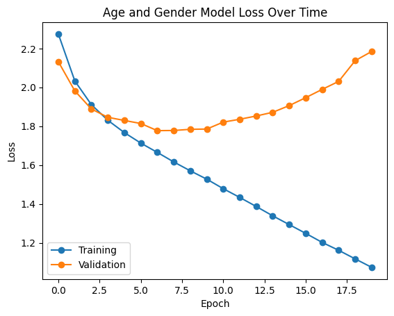

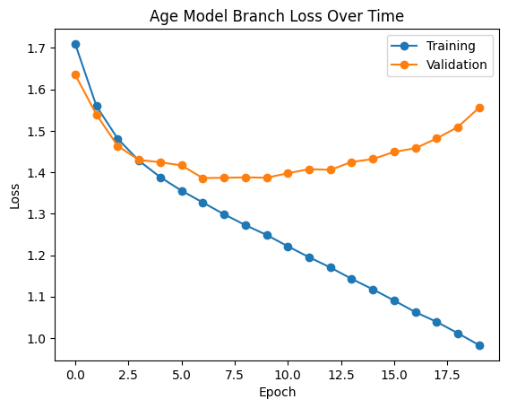

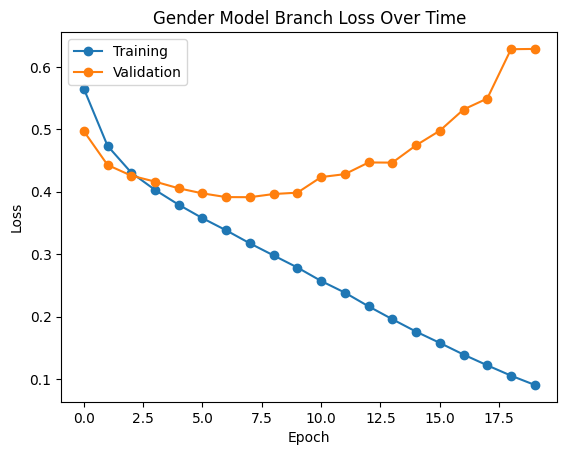

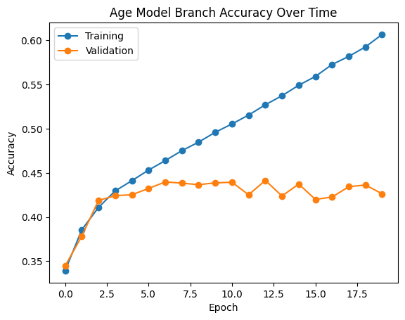

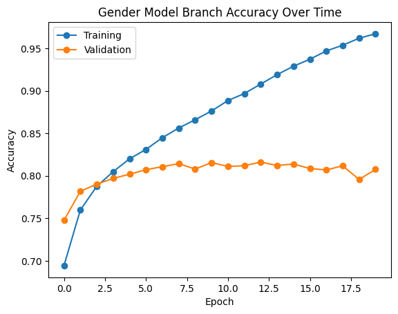

```
Final Classification Accuracy for Age Model Branch: 0.4414825737476349
Final Classification Accuracy for Gender Model Branch: 0.8161402344703674
```

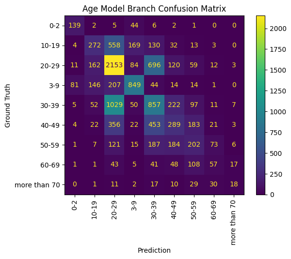

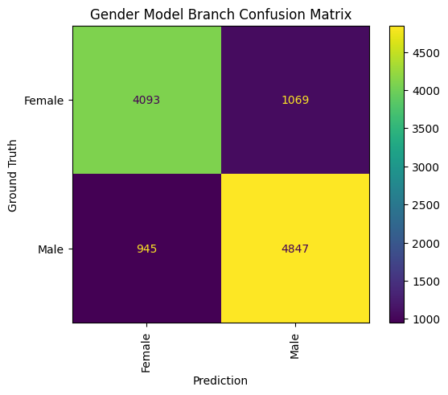

```python
task_4(build_task_4_nn)
```

# Task 5

## Dependencies

```python
def build_task_5_nn() -> tuple:
    latent_dim = 5

    def sampling(args):
        z_mean, z_log_var = args
        epsilon = random_normal(shape=(shape(z_mean)[0], latent_dim))
        return z_mean + exp(0.5 * z_log_var) * epsilon

    # Encoder
    encoder_inputs = Input((32, 32, 1))
    encoder_conv1 = Conv2D(32, 7, strides=2, activation="relu", padding="same")(encoder_inputs)
    encoder_conv2 = Conv2D(48, 3, strides=2, activation="relu", padding="same")(encoder_conv1)
    encoder_flatten = Flatten()(encoder_conv2)
    encoder_dense = Dense(16, activation="relu")(encoder_flatten)
    z_mean = Dense(latent_dim, name="z_mean")(encoder_dense)
    z_log_var = Dense(latent_dim, name="z_log_var")(encoder_dense)
    z = Lambda(sampling, name='z')([z_mean, z_log_var])
    encoder = Model(inputs=encoder_inputs, outputs=[z_mean, z_log_var, z], name="encoder")

    # Decoder
    latent_inputs = Input((latent_dim,))
    decoder_dense = Dense(8 * 8 * 48, activation="relu")(latent_inputs)
    decoder_reshape = Reshape((8, 8, 48))(decoder_dense)
    decoder_conv2dtranspose1 = Conv2DTranspose(48, 3, strides=2, activation="relu", padding="same")(decoder_reshape)
    decoder_conv2dtranspose2 = Conv2DTranspose(32, 7, strides=2, activation="relu", padding="same")(decoder_conv2dtranspose1)
    decoder_conv2dtranspose3 = Conv2DTranspose(1, 7, activation="sigmoid", padding="same")(decoder_conv2dtranspose2)
    decoder = Model(inputs=latent_inputs, outputs=decoder_conv2dtranspose3, name="decoder")

    # VAE
    vae_output = decoder(encoder(encoder_inputs)[2])
    vae = Model(inputs=encoder_inputs, outputs=vae_output, name="vae")
    reconstruction_loss = reduce_mean(reduce_sum(mse(encoder_inputs, vae_output), axis=(1, 2)))
    kl_loss = -0.5 * (1 + z_log_var - square(z_mean) - exp(z_log_var))
    kl_loss = reduce_mean(reduce_sum(kl_loss, axis=1))
    vae_loss = reconstruction_loss + kl_loss
    vae.add_loss(vae_loss)
    vae.compile(optimizer=adamw.AdamW(0.0005, amsgrad=True))
    return encoder, decoder, vae
```

```python
def task_5(func: Callable):
    def plot_history(history, title_str: str) -> None:
        plot(history["loss"], "o-")
        plot(history["val_loss"], "o-")
        legend(["Training", "Validation"])
        title(title_str + " Loss Over Time")
        xlabel("Epoch")
        ylabel("Loss")
        show()

    def train_and_report(title_str: str):
        # Create model and train
        encoder, decoder, vae = func()
        history = vae.fit(scaled_training_data,
                          None,
                          100,
                          10,
                          validation_data=(scaled_validation_data, None))
        history = history.history

        # Create loss and accurracy plots for training and validation data
        plot_history(history, title_str)

        # Generate and display a 5x5 of faces
        figure(figsize=(5, 5))
        _, axs = subplots(5, 5)

        _, _, z = encoder.predict(scaled_training_data)
        rng = default_rng()
        pictures = rng.choice(decoder.predict(z), 25, replace=False)
        print(z.shape)

        for i in range(5):
            for j in range(5):
                axs[i, j].imshow(pictures[i * 5 + j].reshape(32, 32), cmap="gray")
                axs[i, j].axis("off")
        show()

    train_and_report("Variable Auto Encoder Model")
```

## Main

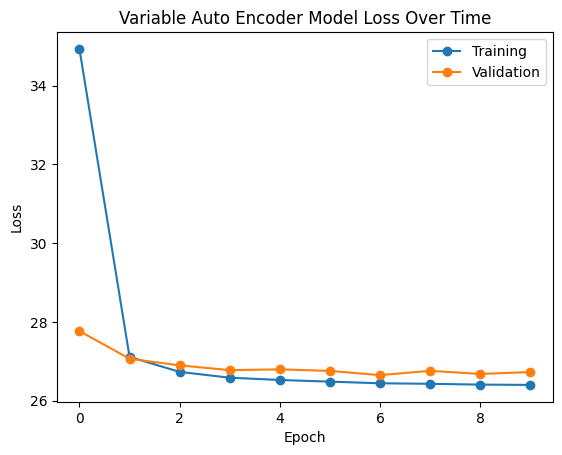

```
(86744, 5)
```

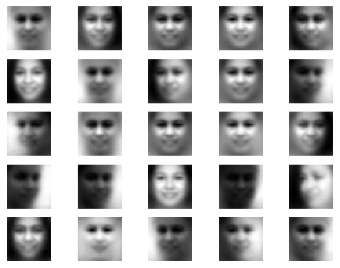

```python
task_5(build_task_5_nn)
```

# Report

## Introduction

The objective of this project was to explore how to create various architectures of Neural Networks through Tensorflow/Keras' API. The scenario is classification of various face attributes (age, gender, and race) based on the FairFace dataset containing 86,744 training face images and 10,954 validation images. By using this scenario for each architecture, we can observe the kind of differences that result from different architectures. Additionally, we explore generative models by making a variational auto encoders to generating new faces.

## Introduction to Networks

### Task 1 Network

The task 1 neural network is a traditional fully connected feed forward type network. The first layer is a `Flatten` layer which takes the inputted image which has dimensions of `(32, 32, 1)` and flattens it into `1024` nodes so that it can be use by the next layer. The second layer is a `Dense` layer with `1024` nodes, presumably 1 for each pixel from the image. It uses the `tanh` activation function. The third layer is another `Dense` layer with `512` nodes, half the previous, and uses the `sigmoid` activation function. The fourth layer is a `Dense` layer with `100` nodes with the `relu` activation function. The final layer is also a `Dense` layer with `n` node where `n` is the number of classes for the face attribute we are trying to classify. It uses the `softmax` activation function, typical for classification tasks. The model is compiled with `categorical_crossentropy` as its loss function and uses the `AMSGrad` version of the newer `AdamW` optimizer with a learning rate of `0.0005` (which we found through trial and error to perform well). The reason we chose `AMSGrad AdamW` is due to the benefits it provides. `AMSGrad`, based on the [paper](https://arxiv.org/pdf/1904.09237.pdf) behind it, shows that `AMSGrad` addresses some convergance issues that `Adam` has and tends to provide better emperical performance. `AdamW` was chosen based on its [paper](https://arxiv.org/pdf/1711.05101.pdf) that demonstrates their decoupling of decaying weights improved emperical performace. A couple comparison runs with `SGD` and `Adam` showed `AdamW` to perform better.

### Task 2 Network

Task 2's neural network is a traditional convolutional type netwok. Layer 1 is a `Conv2D` layer with `40` feature detectors with a kernel size of `5x5`. It uses the `relu` activation function and because it is a `Conv2D` layer, it can directly accept the image as a `(32, 32, 1)`. Following is `MaxPool2D` layer, a typical followup to convolutional layers. The third layer is just a `Flatten` layer to link the 3 dimensional data outputted by the previous layers with the fully connected layers that follow. The fourth and fifth layers are the same as task 1's fourth and fifth layers. This network is also compiled with the same loss function and optimizer as task 1.

### Task 3 Network

Task 3 gave us the freedom to tweak the layers and parameters of Task 2's network. The first change we made was changing the first layer (a `Conv2D`) to use `32` feature detectors instead of `40` with a kernel size of `7x7` instead of `5x5`. The intent was to identify fewer, but larger features from the image of the face. The second change was adding another `Conv2D` layer after the `MaxPool2D` layer with `48` feature detectors and a kernel size of `3x3` with the intent that it would identify the finer features from the previous layer before handed it off to the fully connected layer after it. It used the `relu` activation function chosen simply because the first convolutional layer also used it.

### Task 4 Network

Task 4 was unique as it make us forgo the `Sequential` model and had us classify two attributes at the same time (still centering around a convolutional type network). We decided to use Task 3's network up till the first `Dense` layer where we decopuled the different parts of the network for each attribute we wanted to classify. Each branch had 2 `Dense` layer with `100` nodes and `n` node (n = number of classes), respectively. The first `Dense` layer use the `relu` activation function and the second `softmax`. Both branches used `categorical_crossentropy` and the whole network was trained with `AdamW` with the same parameters as the previous networks.

### Task 5 Network

Task 5 was to make a variational autoencoder (VAE). A VAE model is made of two submodels, an encoder and a decoder. The encoder starts with a `Conv2D` layer with `32` feature detectors, a kernel size of `7x7`, stride of `2`, `relu` activation function, and `same` padding. Following is a `Conv2D` layer with `48` feature detectors, a kernel size of `3x3`, stride of `2`, `relu` activation function, and `same` padding. Aside from the stride and padding, these layers are the same as task 3's with the `MaxPool2D` layer removed. The next layers are a `Flatten` layer and a `Dense` layer with `16` nodes and the `relu` activation function. Now, in order for the VAE to be a VAE, there are 3 layers characteristic of a VAE. The first two are `Dense` layer with `latent_dim` nodes (latent_dim = 5 for this task) and sit side by side getting input from the same layer (the `Dense` layer with `16` nodes). Both of these layers feed into the last layer with is a custom layer (`Lambda`) that given the previous two layers (called `z_mean` and `z_log_var` respectively), call a `sampling` function that conducts a reparameterizatino trick. The decoder is meant to be the inverse of the encoder. It starts with a `Dense` layer with `8 * 8 * 48` node and the `relu` activation function. The node count reflects the output of the last `Conv2D` layer in the encoder. Layer 2 is a `Reshape` that reshapes the input from the previous layer into a `(8, 8, 48)` tensor. That gets passed to a `Conv2DTranspose` with `48` feature detectors, a kernel size of `3x3`, stride of `2`, `relu` activation function, and `same` padding, the same parameters as the last `Conv2D` layer in the encoder. The fourth layer is a `Conv2DTranspose` layer with the same parameters as the 1st `Conv2D` layer of the encoder. The fifth layer is a `Conv2DTranspose` layer with `1` feature detecter (as the input had 1 channel) and a kernel size of `7x7` to match the previous layer with a `sigmoid` activation function and `same` padding. The encoder's input and decoder's output (given the `Lambda` layer output of the encoder) are joined to make the VAE model. This model is given a custom loss function with two parts (that are summed together), the reconstruction loss and the kl divergense loss. The reconstruction loss is mean squared error between the input to the VAE and what the VAE outputs reduced by taking its sum followed by its mean.

## Results

### Task 1 Results

#### Age Model

Evaluation Criteria: Choose the model with the highest `val_accuracy` while fitting on the scaled training data with a batch size of `100` for `20` epochs. Use `categorical crossentropy` for loss.  
Final Classification Accuracy: 39.83%

[figure not shown]

#### Gender Model

Evaluation Criteria: Choose the model with the highest `val_accuracy` while fitting on the scaled training data with a batch size of `100` for `20` epochs. Use `categorical crossentropy` for loss.  
Final Classification Accuracy: 76.62%

[figure not shown]

#### Race Model

Evaluation Criteria: Choose the model with the highest `val_accuracy` while fitting on the scaled training data with a batch size of `100` for `20` epochs. Use `categorical crossentropy` for loss.  
Final Classification Accuracy: 44.65%

[figure not shown]

### Task 2 Results

#### Age Model

Evaluation Criteria: Choose the model with the highest `val_accuracy` while fitting on the scaled training data with a batch size of `100` for `20` epochs. Use `categorical crossentropy` for loss.  
Final Classification Accuracy: 43.39% (+ 3.56% from Task 1)

[figure not shown]

#### Gender Model

Evaluation Criteria: Choose the model with the highest `val_accuracy` while fitting on the scaled training data with a batch size of `100` for `20` epochs. Use `categorical crossentropy` for loss.  
Final Classification Accuracy: 81.09% (+ 4.47% from Task 1)

[figure not shown]

#### Race Model

Evaluation Criteria: Choose the model with the highest `val_accuracy` while fitting on the scaled training data with a batch size of `100` for `20` epochs. Use `categorical crossentropy` for loss.  
Final Classification Accuracy: 48.76% (+ 4.11% from Task 1)

[figure not shown]

### Task 3 Results

#### Age Model

Evaluation Criteria: Choose the model with the highest `val_accuracy` while fitting on the scaled training data with a batch size of `100` for `20` epochs. Use `categorical crossentropy` for loss.  
Final Classification Accuracy: 44.55% (+ 1.16% from Task 2)

[figure not shown]

#### Gender Model

Evaluation Criteria: Choose the model with the highest `val_accuracy` while fitting on the scaled training data with a batch size of `100` for `20` epochs. Use `categorical crossentropy` for loss.  
Final Classification Accuracy: 81.92% (+ 0.83% from Task 2)

[figure not shown]

#### Race Model

Evaluation Criteria: Choose the model with the highest `val_accuracy` while fitting on the scaled training data with a batch size of `100` for `20` epochs. Use `categorical crossentropy` for loss.  
Final Classification Accuracy: 50.88% (+ 2.12% from Task 2)

[figure not shown]

### Task 4 Results

#### Age and Gender Model

Evaluation Criteria: Choose the model with the highest `val_output_a_accuracy` while fitting on the scaled training data with a batch size of `100` for `20` epochs. Use `categorical crossentropy` for loss. In this case, `output_a` was `age`.  
Final Classification Accuracy for Age: 44.15% (- 0.40% from Task 3)  
Final Classification Accuracy for Gender: 81.61% (- 0.31% from Task 3)

[figure not shown]

### Task 5 Results

#### VAE Model

Evaluation Criteria: Use the model after fitting on the scaled training data with a batch size of `100` for `10` epochs. Use the custom loss (reconstruction + kl divergence) mentioned earlier for loss.

[figure not shown]

## Conclusion

First and foremost, for faces, and images in general, convolutional neural networks do a much better job at discovering useful features to distinguish one class from another. Second, parameters matter. We saw a delta as large as 3.5% when using different optimizers with different learning rates. Another interesting obsevation we saw was how quickly (~3-5 epochs) Task 4's branch model reached very low losses compared to the sequential model. Lastly, it seems that VAEs are expensive to train and run which makes sense when considering the copmlexity of what they are designed to achieve. It's likely that other generative types of models are also expensive because of the nature of trying to extrapolate patterns in so many dimensions.

## How to run code

Just run all the cells top down. Make sure you have all the appropriate python packages installed. In particular, ensure the `tensorflow` package is at least version `2.12.0` (the latest version at time of writing) as the optimizer used `AdamW` is not available in older versions.